# EEG Data Curation Part 2

`01_Data_Curation1` 노트북에서 생성한 메타데이터를 불러들여, 이후 학습이 가능하도록 정리하는 노트북.

## 파일 수작업 정리 2

이 노트북을 작성하는 동안, 일부 데이터를 보완 및 수정하였다.

1. 데이터 추가 수집

   나이와 진단명 정보를 더 수집하였다.  
   수집된 나이 정보는 `210429_metadata_나이작업.xlsx`에, 진단명은 `210504_many-to-one_Diagnosis_추가수정.xlsx`에 기록되어 있다.
2. 파일 수정

   일부 파일은 오류가 있어서 수정하였다.
   - `00324958_271118.xlsx`: Sheet48 첫 세 행을 제거, 그 외의 Sheets 제거.
   - `00988278_210915.xlsx`: Sheet56 첫 세 행을 제거, 그 외의 Sheets 제거.
   - `00507286_010915.xlsx`: Sheet72 외의 Sheets 제거.
   - `00414635_240414.xlsx`: Sheet15 외의 Sheets 제거.
   - `00418981_060116.xlsx`: Sheet33 외의 Sheets 제거.
   - `00418981_090316.xlsx`: Sheet34 외의 Sheets 제거.
   - `00421094_140519.xlsx`: Sheet55 외의 Sheets 제거.
   - `00680066_151014.xlsx`: Sheet91 외의 Sheets 제거.
   - `00697249_090414.xlsx`: Sheet5 외의 Sheets 제거.
   - `00700004_270619.xlsx`: Sheet53 외의 Sheets 제거.
   - `00783510_281015.xlsx`: Sheet27 외의 Sheets 제거.
   - `00783510_301115.xlsx`: Sheet28 외의 Sheets 제거.
   - `00783696_220414.xlsx`: Sheet6 외의 Sheets 제거.
   - `00796775_281015.xlsx`: Sheet25 외의 Sheets 제거.
   - `00796775_301115.xlsx`: Sheet26 외의 Sheets 제거.
   - `00823206_130514.xlsx`: Sheet7 외의 Sheets 제거.
   - `00824216_080416.xlsx`: Sheet35 외의 Sheets 제거.
   - `00824216_110516.xlsx`: Sheet36 외의 Sheets 제거.
   - `00875350_140514.xlsx`: Sheet8 외의 Sheets 제거.
   - `00883719_030912.xlsx`: Sheet40 외의 Sheets 제거.
   - `00883719_240812.xlsx`: Sheet41 외의 Sheets 제거.
   - `00957827_230317.xlsx`: Sheet54 외의 Sheets 제거.
   - `00986061_130716.xlsx`: Sheet56 외의 Sheets 제거.
   - `00986061_240215.xlsx`: Sheet57 외의 Sheets 제거.
   - `00986061_270116.xlsx`: Sheet58 외의 Sheets 제거.
   - `00988278_020819.xlsx`: Sheet41 외의 Sheets 제거.
   - `00988278_071119.xlsx`: Sheet40 외의 Sheets 제거.
   - `00988278_160819.xlsx`: Sheet42 외의 Sheets 제거.
   - `00988278_210915.xlsx`: Sheet39 외의 Sheets 제거.
   - `01011922_270815.xlsx`: Sheet23 외의 Sheets 제거.
   - `01011922_290715.xlsx`: Sheet24 외의 Sheets 제거.
   - `01025734_250815.xlsx`: Sheet21 외의 Sheets 제거.
   - `01025734_280715.xlsx`: Sheet22 외의 Sheets 제거.
   - `01026841_101215.xlsx`: Sheet31 외의 Sheets 제거.
   - `01026841_270116.xlsx`: Sheet32 외의 Sheets 제거.
   - `01027623_040416.xlsx`: Sheet45 외의 Sheets 제거.
   - `01027623_060317.xlsx`: Sheet43 외의 Sheets 제거.
   - `01027623_260916.xlsx`: Sheet44 외의 Sheets 제거.
   - `01073369_130514.xlsx`: Sheet9 외의 Sheets 제거.
   - `01080162_120815.xlsx`: Sheet19 외의 Sheets 제거.
   - `01080162_160715.xlsx`: Sheet20 외의 Sheets 제거.
   - `01081922_051115.xlsx`: Sheet29 외의 Sheets 제거.
   - `01081922_071215.xlsx`: Sheet30 외의 Sheets 제거.
   - `01086373_020615.xlsx`: Sheet10 외의 Sheets 제거.
   - `01086373_290415.xlsx`: Sheet11 외의 Sheets 제거.
   - `01126091_140415.xlsx`: Sheet13 외의 Sheets 제거.
   - `01126091_200515.xlsx`: Sheet12 외의 Sheets 제거.
   - `01127836_221116.xlsx`: Sheet46 외의 Sheets 제거.
   - `01139924_060417.xlsx`: Sheet47 외의 Sheets 제거.
   - `01139924_140717.xlsx`: Sheet48 외의 Sheets 제거.
   - `01139924_291214.xlsx`: Sheet49 외의 Sheets 제거.
   - `01139924_300315.xlsx`: Sheet50 외의 Sheets 제거.
   - `01191314_020317.xlsx`: Sheet37 외의 Sheets 제거.
   - `01195277_291215.xlsx`: Sheet4 외의 Sheets 제거.
   - `01207886_270515.xlsx`: Sheet14 외의 Sheets 제거.
   - `01211467_070415.xlsx`: Sheet18 외의 Sheets 제거.
   - `01211467_120515.xlsx`: Sheet17 외의 Sheets 제거.
   - `01243157_141215.xlsx`: Sheet51 외의 Sheets 제거.
   - `01243158_301115.xlsx`: Sheet52 외의 Sheets 제거.
   - `01271175_270416.xlsx`: Sheet37 외의 Sheets 제거.
   - `01271175_300516.xlsx`: Sheet38 외의 Sheets 제거.
   - `01345366_010917.xlsx`: Sheet39 외의 Sheets 제거.
   - `01348720_280917.xlsx`: Sheet38 외의 Sheets 제거.

## 환경 구성

```python
# for auto-reloading external modules
# see http://stackoverflow.com/questions/1907993/autoreload-of-modules-in-ipython
%load_ext autoreload
%autoreload 2
```

```python
# Load some packages
import os
import re
import copy
import glob
import numpy as np
import pyedflib
from openpyxl import load_workbook, Workbook, styles
import json
import datetime
from dateutil.relativedelta import relativedelta
import ctypes
import pprint
import matplotlib.pyplot as plt
import warnings
import string

# custom package
from utils.eeg_dataset import dx1_to_multilabel, MultiLabel
```

```python
# Other settings
%matplotlib inline

# plt.rcParams['figure.figsize'] = (10.0, 8.0) # set default size of plots
# plt.rcParams['image.interpolation'] = 'nearest'
# plt.rcParams['image.cmap'] = 'gray'
# plt.rc('font', family='Malgun Gothic') # for Hangul in Windows
# %config InlineBackend.figure_format = 'retina' # cleaner text
```

## 메타데이터 불러오기

```python
# Data file path
root_path = r'H:\Lab Database\2020 EEG\201020'
original_folder = r'01_Original_Data'
curated_folder = r'02_Curated_Data'
```

```python
meta_file = os.path.join(root_path, r'00_Data_Information/210531_DB_list.xlsx')
ws = load_workbook(meta_file, data_only=True)['metadata']

metadata = []

num = 2
while True:
    m = dict()
    m['edfname'] = ws.cell(row=num, column=1).value
    m['dx1'] = ws.cell(row=num, column=2).value
    m['birth'] = ws.cell(row=num, column=3).value
    m['anomaly'] = True if ws.cell(row=num, column=4).value is not None else False
    num += 1


    # check whether the row is empty (which is EOF condition)
    if m['edfname'] is None:
        break
    elif m['anomaly']:
        continue

    # move the pivot row
    metadata.append(m)

print('Size:', len(metadata))
print()
print(json.dumps(metadata[:3], indent=4))
```

```
Size: 1387

[
    {
        "edfname": "00001809_261018",
        "dx1": "mci_rf",
        "birth": 400602,
        "anomaly": false
    },
    {
        "edfname": "00029426_020817",
        "dx1": "smi",
        "birth": 601204,
        "anomaly": false
    },
    {
        "edfname": "00047327_090718",
        "dx1": "vascular mci",
        "birth": 241019,
        "anomaly": false
    }
]
```

## EDF 파일 구성 확인 및 정리

### EDF Header Label 구조 확인

```python
m = metadata[0]
edf_file = os.path.join(root_path, original_folder, m['edfname'] + '.edf')
signals, signal_headers, edf_header  = pyedflib.highlevel.read_edf(edf_file)

refer_headers = signal_headers

pprint.pp(m)
print()
pprint.pp(edf_header)
print()
pprint.pp(signal_headers)
```

```
{'edfname': '00001809_261018',
 'dx1': 'mci_rf',
 'birth': 400602,
 'anomaly': False}

{'technician': '',
 'recording_additional': '',
 'patientname': '',
 'patient_additional': '',
 'patientcode': '',
 'equipment': '',
 'admincode': '',
 'gender': '',
 'startdate': datetime.datetime(2018, 10, 26, 15, 46, 26),
 'birthdate': '',
 'annotations': []}

[{'label': 'Fp1-AVG',
  'dimension': 'uV',
  'sample_rate': 200,
  'physical_max': 32767.0,
  'physical_min': -32768.0,
  'digital_max': 32767,
  'digital_min': -32768,
  'prefilter': '',
  'transducer': 'E'},
 {'label': 'F3-AVG',
  'dimension': 'uV',
  'sample_rate': 200,
  'physical_max': 32767.0,
  'physical_min': -32768.0,
  'digital_max': 32767,
  'digital_min': -32768,
  'prefilter': '',
  'transducer': 'E'},
 {'label': 'C3-AVG',
  'dimension': 'uV',
  'sample_rate': 200,
  'physical_max': 32767.0,
  'physical_min': -32768.0,
```

[output cut: 151 more lines]

```
  'physical_max': 32767.0,
  'physical_min': -32768.0,
  'digital_max': 32767,
  'digital_min': -32768,
  'prefilter': '',
  'transducer': 'E'},
 {'label': 'Photic',
  'dimension': 'uV',
  'sample_rate': 200,
  'physical_max': 32767.0,
  'physical_min': -32768.0,
  'digital_max': 32767,
  'digital_min': -32768,
  'prefilter': '',
  'transducer': 'E'}]
```

```python
signal_labels = [s_h['label'] for s_h in signal_headers]
print(signal_labels)
```

```
['Fp1-AVG', 'F3-AVG', 'C3-AVG', 'P3-AVG', 'O1-AVG', 'Fp2-AVG', 'F4-AVG', 'C4-AVG', 'P4-AVG', 'O2-AVG', 'F7-AVG', 'T3-AVG', 'T5-AVG', 'F8-AVG', 'T4-AVG', 'T6-AVG', 'FZ-AVG', 'CZ-AVG', 'PZ-AVG', 'EKG', 'Photic']
```

### EDF 신호열의 Trailing Zero Columns 제거 테스트

```python
def trim_zero_columns(a):
    assert type(a) == np.ndarray
    for i in range(a.shape[-1]):
        if np.any(a[..., -1 - i] != 0):
            break
    a = a[..., :-i]
    return a
```

```python
for (i, m) in enumerate(metadata):
    edf_file = os.path.join(root_path, original_folder, m['edfname'] + '.edf')
    signals, signal_headers, edf_header  = pyedflib.highlevel.read_edf(edf_file)
    signals = trim_zero_columns(signals)
    print(m['edfname'], end='\t\t')
    print(edf_header['startdate'], end='\t')
    print(edf_header['startdate'] + datetime.timedelta(seconds = signals.shape[1] / 200), end='\t')
    print()

    if i > 10:
        break
```

```
00001809_261018		2018-10-26 15:46:26	2018-10-26 15:58:31
00029426_020817		2017-08-02 16:14:56	2017-08-02 16:32:14
00047327_090718		2018-07-09 15:29:10	2018-07-09 15:40:00
00048377_070819		2019-08-07 13:55:25	2019-08-07 14:09:26
00048377_070916		2016-09-07 10:36:01	2016-09-07 10:51:16
00048377_250719		2019-07-25 09:58:07	2019-07-25 10:12:04
00050941_130116		2016-01-13 13:45:54	2016-01-13 14:00:54
00055757_170414		2014-04-17 13:33:15	2014-04-17 13:41:33
00056270_260219		2019-02-26 10:38:59	2019-02-26 10:56:33
00062072_080319		2019-03-08 13:38:26	2019-03-08 13:55:08
00088513_120717		2017-07-12 14:15:27	2017-07-12 14:30:43
00110793_210917		2017-09-21 14:25:09	2017-09-21 14:37:51
```

## EDF 측정시 발생하는 이벤트 확인 & 메타데이터 기록 시간과 비교

```
[('Eyes Closed', 16870),
 ('Eyes Open', 16818),
 ('Photic Off', 10442),
 ('Paused', 1874),
 ('Move', 1777),
 ('Start Recording', 1387),
 ('New Montage - Montage 002', 1099),
 ('Photic On - 3.0 Hz', 1070),
 ('Photic On - 6.0 Hz', 1062),
 ('Photic On - 9.0 Hz', 1060),
 ('Photic On - 12.0 Hz', 1057),
 ('Photic On - 15.0 Hz', 1051),
 ('Photic On - 21.0 Hz', 1048),
 ('Photic On - 18.0 Hz', 1045),
 ('Photic On - 24.0 Hz', 1032),
 ('Photic On - 27.0 Hz', 1020),
 ('Photic On - 30.0 Hz', 977),
 ('Recording Resumed', 492),
 ('artifact', 367),
 ('swallowing', 232),
 ('New Montage - Pz Montage', 164),
 ('New Montage - Montage 005', 147),
 ('HV - Off', 97),
 ('cough', 53),
 ('Talk', 51),
 ('HV fair', 49),
 ('chewing', 47),
 ('passive eye close', 36),
 ('A1 recheck', 24),
 ('HV Fair', 23),
 ('Artifact', 23),
 ('eye blinking -->>', 21),
 ('sleep Try', 20),
 ('A2 recheck', 18),
 ('eye blinking', 17),
 ('T3 check', 15),
 ('T4 recheck', 13),
 ('Couch', 13),
 ('F4 recheck', 12),
 ('A2 Recheck', 12),
```

[output cut: 254 more lines]

```
 ('Fp1 check', 1),
 ('HV - Dur: 179.2 sec. - On', 1),
 ('Drowsy', 1),
 ('HV - Dur: 181.7 sec. - On', 1),
 ('sweat +++++++++', 1),
 ('HV - Dur: 173.3 sec. - On', 1),
 ('A1, A2 Recheck', 1),
 ('Fp2 check', 1),
 ('HV - Dur: 180.9 sec. - On', 1),
 ('eye blink', 1),
 (' check', 1),
 ('HV - Dur: 180.7 sec. - On', 1),
 ('F8,T3,C3 check', 1),
 ('HV - Dur: 181.5 sec. - On', 1),
 ('HV - Dur: 175.4 sec. - On', 1)]
```

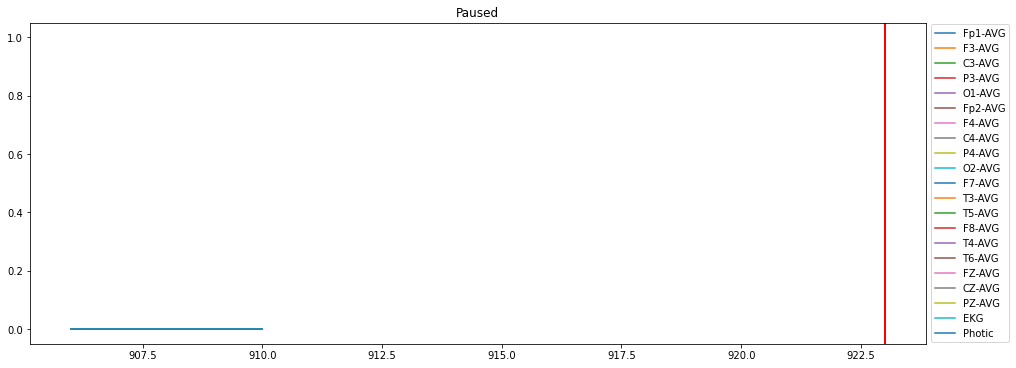

```python
warnings.filterwarnings(action='ignore')

text = f'Do you want to draw the plots to compare the event and signal timing? \
{os.path.join(root_path, curated_folder)}?'
draw = True if ctypes.windll.user32.MessageBoxExW(0, text, 'Question', 4) == 6 else False

event_dict = dict()
for m in metadata:
    edf_file = os.path.join(root_path, original_folder, m['edfname'] + '.edf')
    signals, signal_headers, edf_header = pyedflib.highlevel.read_edf(edf_file)

    event_file = os.path.join(root_path, original_folder, m['edfname'] + '.xlsx')
    wb = load_workbook(event_file, data_only=True)
    ws = wb[wb.sheetnames[0]]

    num = 2
    events = []
    while True:
        t = ws.cell(row=num, column=3).value
        e = ws.cell(row=num, column=4).value

        if t is None:
            break

        try:
            t = edf_header['startdate'].strftime('%Y%m%d') + t
            t = datetime.datetime.strptime(t, '%Y%m%d %H:%M:%S.%f')
            event_dict[e] = event_dict.get(e, 0) + 1
        except Exception as ec:
            print(edf_header['startdate'], m['edfname'], ec)

        if num == 2:
            startTime = t
            diff = abs(edf_header['startdate'] - t).total_seconds()
            if diff > 0.0:
                print(f'- EDF and XLSX files have different starting time: \
                {diff:>10.2f}s in {m["edfname"]} ({edf_header["startdate"].strftime("%H:%M:%S")} vs {t.strftime("%H:%M:%S")})')

        t = int(np.floor((t - startTime).total_seconds() * 200))
        events.append((t, e))
        num += 1

    if draw:
        path = 'output/imgs/{}'.format(m['edfname'])
        os.makedirs(path, exist_ok=True)

        for i, (t, e) in enumerate(events):
            fig = plt.figure(num=1, clear=True,
                             figsize=(14.0, 5), constrained_layout=True)
            ax = fig.add_subplot(1, 1, 1)

            width = 400
            st, et = t - width, t + width
            if st < 0:
                st, et = 0, width*2
            elif signals.shape[1] < et:
                st, et = signals.shape[1] - width*2, signals.shape[1]

            for (k, label) in enumerate(signal_labels):
                ax.plot(np.arange(st, et) / 200, signals[k, st:et], label=label)
                ax.vlines([t / 200], 0, 1, transform=ax.get_xaxis_transform(), colors='r')

            ax.legend(loc='center left', bbox_to_anchor=(1, 0.5))
            ax.set_title(e)

            fname = f'{str(i+1):>03}_{e}.png'
            safechars = string.ascii_lowercase + string.ascii_uppercase + string.digits + '.-_'
            fname = ''.join([c for c in fname if c in safechars])

            fig.savefig(os.path.join(path, fname))

print()
pprint.pprint(sorted(event_dict.items(), key=lambda x: x[1], reverse=True))

warnings.filterwarnings(action='default')
```

## 데이터셋 구성 및 저장

1. EDF / Signal Header Label 불일치 데이터 제거
2. EDF $\rightarrow$ NumPy Pickle 변환하여 저장
3. Metadata 정리 후 저장
   - `metadata_debug`: 디버깅을 위해 모든 정보를 총망라한 버전
   - `metadata_public`: 익명화까지 수행하여 향후 공개가 가능한 버전

```python
def birth_to_datetime(b):
    if b is None:
        return None
    try:
        if type(b) is int:
            y = (b // 10000) + 1900
            m = (b % 10000) // 100
            d = b % 100
            return datetime.date(y, m, d)
        elif type(b) is str:
            b = int(b)
            y = (b // 10000) + 1900
            m = (b % 10000) // 100
            d = b % 100
            return datetime.date(y, m, d)
    except:
        print(f'WARNING - Input to birth_to_datetime() is uninterpretable: {type(b)}, {b}')
    return None


def calculate_age(birth, record):
    if birth is None:
        return None
    try:
        age = (record - relativedelta(years=birth.year, months=birth.month, days=birth.day)).year
        if age < 40 or 100 < age:
            print(f'WARNING - calculate_age() generated an unordinary age: {age}')
        return age
    except Exception as e:
        print(f'WARNING - calculate_age() has an exception: {e}')
    return None


def serialize_json(obj):
    """JSON serializer for objects not serializable by default json code"""

    if isinstance(obj, datetime.datetime) or isinstance(obj, datetime.date):
        serial = obj.isoformat()
        return serial

    if isinstance(obj, MultiLabel):
        serial = obj.get_active_dict()
        return serial

    return obj.__dict__
```

```python
warnings.filterwarnings(action='ignore')

text = f'Delete ALL files in {os.path.join(root_path, curated_folder)}?'
if ctypes.windll.user32.MessageBoxExW(0, text, 'Question', 4) == 6: # Yes
    for f in glob.glob(os.path.join(root_path, curated_folder, '*.*')):
        os.remove(f)

metadata_debug = []
metadata_public = []

for m in metadata[:5]:
    # EDF file check
    edf_file = os.path.join(root_path, original_folder, m['edfname'] + '.edf')
    signals, signal_headers, edf_header = pyedflib.highlevel.read_edf(edf_file)

    if refer_headers != signal_headers:
        print('- Signal header differs from the majority:', m['edfname'])
        continue

    # calculate age
    age = calculate_age(birth_to_datetime(m['birth']),
                        edf_header['startdate'])

    # EDF recoding events
    event_file = os.path.join(root_path, original_folder, m['edfname'] + '.xlsx')
    wb = load_workbook(event_file, data_only=True)
    ws = wb[wb.sheetnames[0]]

    num = 2
    events = []

    while True:
        t = ws.cell(row=num, column=3).value
        e = ws.cell(row=num, column=4).value

        if t is None:
            break

        t = edf_header['startdate'].strftime('%Y%m%d') + t
        t = datetime.datetime.strptime(t, '%Y%m%d %H:%M:%S.%f')

        if num == 2:
            startTime = t

        t = int(np.floor((t - startTime).total_seconds() * 200))
        events.append((t, e))
        num += 1

    # metadata_debug
    m2 = {}
    m2['serial'] = f'{len(metadata_debug) + 1:05}'
    m2['edfname'] = m['edfname']
    m2['birth'] = birth_to_datetime(m['birth'])
    m2['record'] = edf_header['startdate']
    m2['age'] = age
    m2['dx1'] = m['dx1']
    m2['label'] = dx1_to_multilabel(m['dx1'])
    m2['events'] = events
    metadata_debug.append(m2)

    # metadata_public
    m3 = {}
    m3['serial'] = m2['serial']
    m3['age'] = age
    m3['label'] = m2['label']
    metadata_public.append(m3)

    # EDF signal
    signals = trim_zero_columns(signals)
    fname = os.path.join(root_path, curated_folder, m2['serial'])
    np.save(fname, signals)

print(f'Among {len(metadata)}, {len(metadata_public)} data were saved.')

warnings.filterwarnings(action='default')
```

```
Among 1387, 5 data were saved.
```

```python
pprint.pp(metadata_debug[:5])
```

```
[{'serial': '00001',
  'edfname': '00001809_261018',
  'birth': datetime.date(1940, 6, 2),
  'record': datetime.datetime(2018, 10, 26, 15, 46, 26),
  'age': 78,
  'dx1': 'mci_rf',
  'label': MultiLabel{'mci': True, 'mci_amnestic': True, 'mci_amnestic_rf': True},
  'events': [(0, 'Start Recording'),
             (0, 'New Montage - Montage 002'),
             (36396, 'Eyes Open'),
             (72518, 'Eyes Closed'),
             (73862, 'Eyes Open'),
             (75248, 'Eyes Closed'),
             (76728, 'swallowing'),
             (77978, 'Eyes Open'),
             (79406, 'Eyes Closed'),
             (79996, 'Photic On - 3.0 Hz'),
             (80288, 'Eyes Open'),
             (81296, 'Eyes Closed'),
             (82054, 'Photic Off'),
             (84070, 'Photic On - 6.0 Hz'),
             (84488, 'Eyes Open'),
             (85538, 'Eyes Closed'),
             (86086, 'Photic Off'),
             (88144, 'Photic On - 9.0 Hz'),
             (90160, 'Photic Off'),
             (91458, 'Eyes Open'),
             (92218, 'Photic On - 12.0 Hz'),
             (92762, 'Eyes Closed'),
             (94198, 'Photic Off'),
             (94742, 'Eyes Open'),
             (95708, 'Eyes Closed'),
             (96256, 'Photic On - 15.0 Hz'),
             (98272, 'Photic Off'),
             (100330, 'Photic On - 18.0 Hz'),
             (102346, 'Photic Off'),
             (102596, 'Eyes Open'),
             (103856, 'Eyes Closed'),
             (104361, 'Photic On - 21.0 Hz'),
             (106420, 'Photic Off'),
```

[output cut: 282 more lines]

```
             (145740, 'Eyes Closed'),
             (147168, 'Eyes Open'),
             (148428, 'Eyes Closed'),
             (150402, 'Eyes Open'),
             (151956, 'Eyes Closed'),
             (165320, 'Eyes Open'),
             (165734, 'Move'),
             (166328, 'Eyes Closed'),
             (167672, 'Eyes Open'),
             (168848, 'Eyes Closed'),
             (170318, 'Eyes Open'),
             (171578, 'Eyes Closed'),
             (178976, 'Eyes Open'),
             (180404, 'Eyes Closed'),
             (183000, 'Paused')]}]
```

```python
pprint.pp(metadata_public[:5])
```

```
[{'serial': '00001',
  'age': 78,
  'label': MultiLabel{'mci': True, 'mci_amnestic': True, 'mci_amnestic_rf': True}},
 {'serial': '00002',
  'age': 56,
  'label': MultiLabel{'normal': True, 'smi': True}},
 {'serial': '00003',
  'age': 93,
  'label': MultiLabel{'mci': True, 'mci_vascular': True}},
 {'serial': '00004',
  'age': 78,
  'label': MultiLabel{'dementia': True, 'ad': True, 'load': True}},
 {'serial': '00005',
  'age': 75,
  'label': MultiLabel{'dementia': True, 'ad': True, 'load': True}}]
```

```python
# save metadata_public as JSON
path = os.path.join(root_path, curated_folder, 'metadata_public.json')
with open(path, 'w') as json_file:
    json.dump(metadata_public, json_file, indent=4, default=serialize_json)

# save metadata_public as XLSX
wb = Workbook()
ws = wb.active
ws.title = 'metadata'
ws.cell(row=1, column=1).value = 'serial'
ws.cell(row=1, column=2).value = 'age'
for (i, label) in enumerate(metadata_debug[0]['label'].get_label_types()):
    ws.cell(row=1, column=3 + i).value = label

for (i, m) in enumerate(metadata_debug):
    ws.cell(row=2 + i, column=1).value = m['serial']
    ws.cell(row=2 + i, column=2).value = m['age']
    for (k, label) in enumerate(m['label'].get_label_values()):
        ws.cell(row=2 + i, column=3 + k).value = label if label is not False else None

    # coloring
    color = 'FDFDD0' if i % 2 == 0 else 'D9E5FF'
    for rows in ws.iter_rows(min_row=2 + i, max_row=2 + i, min_col=1, max_col=2 + m['label'].get_size()):
        for cell in rows:
            cell.fill = styles.PatternFill(start_color=color, end_color=color, fill_type="solid")

path = os.path.join(root_path, curated_folder, 'metadata_public.xlsx')
wb.save(path)
```

```python
# save metadata_debug as JSON
path = os.path.join(root_path, curated_folder, 'metadata_debug.json')
with open(path, 'w') as json_file:
    json.dump(metadata_debug, json_file, indent=4, default=serialize_json)

# save metadata_debug as XLSX
wb = Workbook()
ws = wb.active
ws.title = 'metadata'
ws.cell(row=1, column=1).value = 'serial'
ws.cell(row=1, column=2).value = 'EDF file'
ws.cell(row=1, column=3).value = 'birth'
ws.cell(row=1, column=4).value = 'record'
ws.cell(row=1, column=5).value = 'age'
ws.cell(row=1, column=6).value = 'dx1'
for (i, label) in enumerate(metadata_debug[0]['label'].get_label_types()):
    ws.cell(row=1, column=7 + i).value = label

for (i, m) in enumerate(metadata_debug):
    ws.cell(row=2 + i, column=1).value = m['serial']
    ws.cell(row=2 + i, column=2).value = m['edfname']
    ws.cell(row=2 + i, column=3).value = m['birth']
    ws.cell(row=2 + i, column=4).value = m['record']
    ws.cell(row=2 + i, column=5).value = m['age']
    ws.cell(row=2 + i, column=6).value = m['dx1']
    for (k, label) in enumerate(m['label'].get_label_values()):
        ws.cell(row=2 + i, column=7 + k).value = label if label is not False else None

    # coloring
    color = 'FDFDD0' if i % 2 == 0 else 'D9E5FF'
    for rows in ws.iter_rows(min_row=2 + i, max_row=2 + i, min_col=1, max_col=6 + m['label'].get_size()):
        for cell in rows:
            cell.fill = styles.PatternFill(start_color=color, end_color=color, fill_type="solid")

path = os.path.join(root_path, curated_folder, 'metadata_debug.xlsx')
wb.save(path)
```